# SupplementaryInfo_GibsonHay_LaS

Andy Gibson, Jen Hay

2023-12-15

# Perceptual Style-shifting across Singing and Speech: Music activates Pop Song English for NZ Listeners

## Supplementary Materials

Andy Gibson and Jen Hay

## Contents

- This R Markdown file contains the code used for running the three models presented in the article, as well as for generating the plots.
1. Prerequisites
2. Read in Experiment 1 (PCT) data
3. Run Experiment 1 model
4. Plot Experiment 1 model predictions
5. Read in Experiment 2 (LDT) data
6. Run Experiment 2 accuracy model
7. Run Experiment 2 reaction time model
8. Plot Experiment 2 reaction time model predictions

## Prerequisites : load libraries

```r
### load libraries ====
library(tidyverse) # data wrangling
library(lme4) # run models
library(effects) # get model predictions
library(emmeans) # do pairwise analyses
library(lmerTest) # estimate p-values when summarising lmer models
library(xtable) # get tables formatted for latex


# set up vif.mer function for later
vif.mer <- function (fit) {
  ## adapted from rms::vif

  v <- vcov(fit)
  nam <- names(fixef(fit))
  ## exclude intercepts
  ns <- sum(1 * (nam == "Intercept" | nam == "(Intercept)"))
  if (ns > 0) {
    v <- v[-(1:ns), -(1:ns), drop = FALSE]
    nam <- nam[-(1:ns)]
  }

  d <- diag(v)^0.5
  v <- diag(solve(v/(d %o% d)))
  names(v) <- nam
  v
}


## set up a function for knitting model outputs tidily

tableify <- function(model) {
require(dplyr)
smry <- coef(summary(model)) %>% as.data.frame()
df <- smry %>%
mutate_at(c("Estimate", "Std. Error"), round, 5) %>%
mutate_at(vars(matches("[tz] value")), round, 3) %>%
mutate_at(vars(matches("^df$")), round, 0)
rownames(df) <- rownames(smry)
df
}




###  cool function from dan villareal's workshop on effects package and ggplot that let's you keep
# levels of factors the way you want them.
df.eff <- function (x, row.names = NULL, optional = TRUE, transform = x$transformation$inverse,
                    ...) {
  if (class(x)!="eff") stop("x must be of class eff")
  xx <- x$x
  for (var in names(xx)) {
    if (is.factor(xx[[var]])) {
      ##Fix the issue where levels(xx[[var]]!=(unique(xx[[var]])==levels(origDF[[var]])))
      xx[[var]] <- addNA(factor(xx[[var]], levels=unique(xx[[var]])))
    }
  }
  x$x <- xx
  result <- if (is.null(x$se))
    data.frame(x$x, fit = transform(x$fit))
  else data.frame(x$x, fit = transform(x$fit), se = x$se,
                  lower = transform(x$lower), upper = transform(x$upper))
  attr(result, "transformation") <- transform
  result
}
```

# EXPERIMENT 1: PHONEME CATEGORISATION TASK (PCT)

## Read in Experiment 1 data

```r
dat1 <- read.csv("Data/PCT_rawData.csv")

# Let's swap the reference level for stimlength
dat1$StimLength <- as.factor(dat1$StimLength)
dat1$StimLength <- relevel(dat1$StimLength, ref = "Short")
```

For this analysis, we are only interested in music vs. non music. so we can set up specific contrast coding. This contrast coding method comes from [here](https://stats.oarc.ucla.edu/r/library/r-library-contrast-coding-systems-for-categorical-variables/#User) and [here](https://marissabarlaz.github.io/portfolio/contrastcoding/#:~:text=By%20default%2C%20a%20variable%20does,or%20define%20any%20contrast%20manually)

Some relevant quotes from the 2nd link: Another example of contrast coding would be, say we had three groups: English, Spanish, and French speakers, who participated in a lexical decision task. If we wanted to, we could compare between English and non-English (i.e., Spanish and French), and then between Spanish and French speakers. The contrast for that would look like this:

```r
matrix(c(1, -1/2, -1/2, 0, .5, -.5), ncol = 2)
```

```
##      [,1] [,2]
## [1,]  1.0  0.0
## [2,] -0.5  0.5
## [3,] -0.5 -0.5
```

```r
# keep the original version with built-in treatment coding
dat1$ConditionTreatment <- as.factor(dat1$Condition)
# now make the version with custom contrasts
dat1$Condition <- as.factor(dat1$Condition)
mycontrasts2 = contrasts(dat1$Condition)
mycontrasts2[,1] = c(1, -1/2, -1/2)
mycontrasts2[,2] = c(0,.5,-.5)
colnames(mycontrasts2) <- c("Music_vs_NonMusic", "Noise_vs_Silence")
mycontrasts2
```

```
##         Music_vs_NonMusic Noise_vs_Silence
## Music                 1.0              0.0
## Noise                -0.5              0.5
## Silence              -0.5             -0.5
```

```r
contrasts(dat1$Condition) = mycontrasts2
contrasts(dat1$Condition)
```

```
##         Music_vs_NonMusic Noise_vs_Silence
## Music                 1.0              0.0
## Noise                -0.5              0.5
## Silence              -0.5             -0.5
```

Get rid of outliers as per preregistration. NB. nobody removed for having overall fast or slow reaction times, and none removed for ‘onset delay’ in eprime.

```r
# drop all tokens where the reaction time is 3 by-speaker standard deviations
# above or below the by-speaker mean

# first get the mean and sd for each participant
dat1 %>% group_by(Participant) %>%summarise(meanRT = mean(RT),
                                      sdRT = sd(RT)) -> means
# make the by-participant cut-offs outside 3 sds
means %>% mutate(topRT = meanRT + 3*sdRT, botRT = meanRT - 3*sdRT) -> means
# merge the cutoffs back into the main data
left_join(dat1,means) -> dat1
# remove those where RT is above the cutoff
dat1 %>% filter(RT < topRT) -> dat1 # 2592>2548 cut 44 trials
# remove those where RT is below the cutoff
dat1 %>% filter(RT > botRT) -> dat1 # 2548>2547 cut 1 trial
```

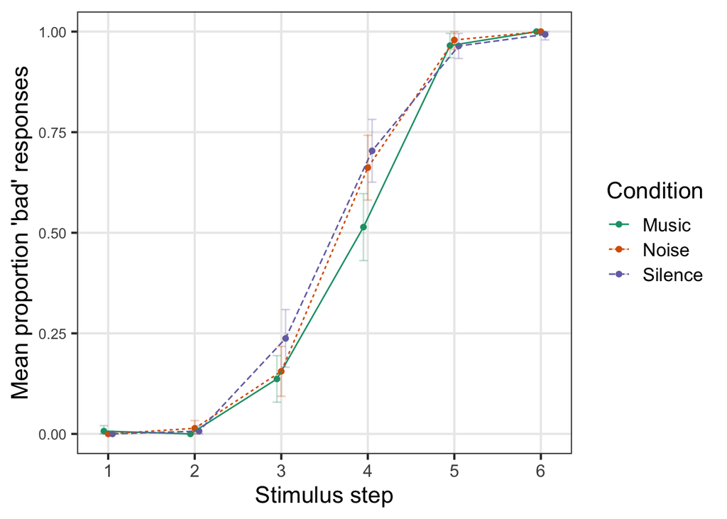

```r
# creating raw data plot


# getting 95% confidence intervals

dat1 %>% group_by(Condition, StimStep) %>%
  summarise(
    meanResp = mean(Response, na.rm = T),
    sd = sd(Response, na.rm = T),
    n = n()) %>%
  mutate(
    se = sd/sqrt(n),
    lower.ci = meanResp - qt(1 - (0.05 / 2), n - 1) * se,
    upper.ci = meanResp + qt(1 - (0.05 / 2), n - 1) * se) -> meanBad
# make a bit of horizontal space:
meanBad$StimStep <- ifelse(meanBad$Condition=="Music",meanBad$StimStep-0.05,meanBad$StimStep)
meanBad$StimStep <- ifelse(meanBad$Condition=="Silence",meanBad$StimStep+0.05,meanBad$StimStep)


### make min 0 and max 1
meanBad$lower.ci <- ifelse(meanBad$lower.ci < 0, 0, meanBad$lower.ci)
meanBad$upper.ci <- ifelse(meanBad$upper.ci > 1, 1, meanBad$upper.ci)

meanBad %>% ggplot(aes(y=meanResp, x=StimStep, colour = Condition, linetype=Condition,
                       ymin = lower.ci, ymax = upper.ci)) +
  geom_point() +
  geom_line() +
  geom_errorbar(width=.1, linetype=1,alpha=0.3) +
  scale_y_continuous("Mean proportion 'bad' responses", minor_breaks = NULL) +
  scale_x_continuous(
    name = "Stimulus step", breaks = 1:6, minor_breaks = NULL) +
  theme_bw(base_size = 16) +
  theme(axis.text.y = element_text(size=10), axis.text.x = element_text(size=12)) +
  scale_colour_brewer(palette = 'Dark2')
```

```r
# save the plot if you like!
# ggsave('PCT_rawDataSummary.png', width=7, height=5.5)
```

## Run Experiment 1 model

```r
PCT_mod = glmer(Response ~ Condition * Trial24 +
              + StimStep + StimLength + PrevStimStep + (1|Participant),
            data = dat1,  family = "binomial", glmerControl(optimizer = "bobyqa"))
#summary(PCT_mod)
#

# pretty knitting of model summary from Jen's funtion (see prerequisites section):
pctTable = tableify(PCT_mod)
knitr::kable(pctTable, caption="Model of PCT responses")
```

Model of PCT responses

|  | Estimate | Std. Error | z value | Pr(>\|z\|) |
| --- | --- | --- | --- | --- |
| (Intercept) | -10.24554 | 0.60524 | -16.928 | 0.0000000 |
| ConditionMusic_vs_NonMusic | -1.21673 | 0.23580 | -5.160 | 0.0000002 |
| ConditionNoise_vs_Silence | -0.88975 | 0.41172 | -2.161 | 0.0306894 |
| Trial24 | -0.02735 | 0.01192 | -2.294 | 0.0217753 |
| StimStep | 3.12139 | 0.15359 | 20.323 | 0.0000000 |
| StimLengthLong | 1.00029 | 0.18263 | 5.477 | 0.0000000 |
| PrevStimStep | -0.42240 | 0.05802 | -7.280 | 0.0000000 |
| ConditionMusic_vs_NonMusic:Trial24 | 0.05745 | 0.01661 | 3.459 | 0.0005422 |
| ConditionNoise_vs_Silence:Trial24 | 0.04292 | 0.02921 | 1.469 | 0.1417222 |

Check the VIF on the model

```r
vif.mer(PCT_mod)
```

Max VIF = 3.6. No problem with collinearity

## PCT model to check the individual non-music conditions against music

```r
PCT_mod_Treatment = glmer(Response ~ ConditionTreatment * Trial24 +
              + StimStep + StimLength + PrevStimStep + (1|Participant),
            data = dat1,  family = "binomial", glmerControl(optimizer = "bobyqa"))
#summary(PCT_mod_Treatment)
#

# pretty knitting of model summary from Jen's funtion (see prerequisites section):
pctTable = tableify(PCT_mod_Treatment)
knitr::kable(pctTable, caption="Model of PCT responses")
```

Model of PCT responses

|  | Estimate | Std. Error | z value | Pr(>\|z\|) |
| --- | --- | --- | --- | --- |
| (Intercept) | -11.46225 | 0.68584 | -16.713 | 0.0000000 |
| ConditionTreatmentNoise | 1.38020 | 0.40238 | 3.430 | 0.0006033 |
| ConditionTreatmentSilence | 2.26997 | 0.41600 | 5.457 | 0.0000000 |
| Trial24 | 0.03010 | 0.02009 | 1.498 | 0.1341147 |
| StimStep | 3.12138 | 0.15359 | 20.323 | 0.0000000 |
| StimLengthLong | 1.00029 | 0.18263 | 5.477 | 0.0000000 |
| PrevStimStep | -0.42240 | 0.05802 | -7.280 | 0.0000000 |
| ConditionTreatmentNoise:Trial24 | -0.06472 | 0.02894 | -2.236 | 0.0253509 |
| ConditionTreatmentSilence:Trial24 | -0.10764 | 0.02881 | -3.736 | 0.0001871 |

## Plot Experiment 1 model predictions

```r
### cond*trial
PCT_mod %>%
  Effect(c("Condition","Trial24"), .) %>%   df.eff()
```

```
##    Condition Trial24       fit        se     lower     upper
## 1      Music     1.0 0.1808251 0.3302055 0.1035899 0.2965926
## 2      Noise     1.0 0.4513372 0.3287989 0.3015973 0.6104406
## 3    Silence     1.0 0.6573643 0.3350025 0.4987444 0.7872056
## 4      Music     6.8 0.2081375 0.2675757 0.1346299 0.3075177
## 5      Noise     6.8 0.4022544 0.2639828 0.2862888 0.5302919
## 6    Silence     6.8 0.5502918 0.2667090 0.4204588 0.6736169
## 7      Music    12.0 0.2351116 0.2472285 0.1591952 0.3328971
## 8      Noise    12.0 0.3598263 0.2457019 0.2577521 0.4763797
## 9    Silence    12.0 0.4498324 0.2419298 0.3372615 0.5677865
## 10     Music    18.0 0.2691241 0.2759773 0.1765386 0.3874211
## 11     Noise    18.0 0.3134898 0.2813206 0.2082952 0.4421414
## 12   Silence    18.0 0.3392639 0.2691897 0.2325125 0.4653123
## 13     Music    24.0 0.3060880 0.3468007 0.1826957 0.4653667
## 14     Noise    24.0 0.2705982 0.3599233 0.1548540 0.4289459
## 15   Silence    24.0 0.2438282 0.3419151 0.1416144 0.3865913
```

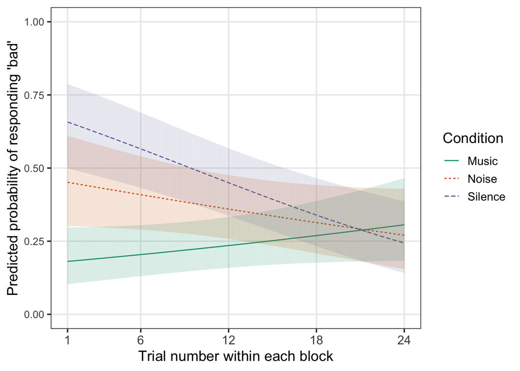

```r
PCT_mod %>%
  Effect(c("Condition","Trial24"), ., xlevels = 1000) %>%
  df.eff() %>%
  ggplot(aes(x=Trial24, y=fit, group=Condition, colour=Condition, linetype = Condition, ymin=lower, ymax=upper)) +
  geom_path() +
  geom_errorbar(width=0, alpha = 0.05, linetype=1) +
  scale_y_continuous("Predicted probability of responding 'bad'", limits = c(0,1), minor_breaks = NULL) +
  scale_x_continuous('Trial number within each block', minor_breaks = NULL, limits = c(1,24), breaks = c(1,6,12,18,24), labels = c("1","6", "12","18", "24")) +
  theme_bw(base_size = 14) +
  theme(axis.text.y = element_text(size=10), axis.text.x = element_text(size=12)) +
  scale_colour_brewer(palette = 'Dark2')
```

```r
# save the plot if you like!
# ggsave('PCT_mod.png', width=7, height=5.5)
```

# EXPERIMENT 2: LEXICAL DECISION TASK (LDT)

## Read in Experiment 2 (LDT) data

The data file should be in a folder called “Data” that is in the same location as this Rmd file. Alternatively, you can change the path below yourself to find the file.

```r
dat2 <- read.csv("Data/LDT_rawData.csv")
```

We need to remove outliers and nonwords, log and scale some variables, and create custom contrast coding

### Remove outliers and nonwords

```r
# drop all tokens with rt < 400ms
dat2 %>% filter(RT >399) -> dat2 # 55 items removed

# drop all tokens where the reaction time is 3 by-speaker standard deviations
# above the by-speaker mean

# first get the mean and sd for each participant
dat2 %>% group_by(Participant) %>%summarise(meanRT = mean(RT),
                                      sdRT = sd(RT)) -> means
# make the by-participant cut-offs outside 3 sds
means %>% mutate(topRT = meanRT + 3*sdRT) -> means
# merge the cutoffs back into the main data
left_join(dat2,means) -> dat2
# remove those where RT is above the cutoff
dat2 %>% filter(RT < topRT) -> dat2 # cut 174 tokens, from 10745 to 10571

# get rid of all nonwords
dat2 %>% filter(StimulusType == "Word") -> dat2 # down to 5308 trials
```

### Manipulate variables

```r
# log and scale RT, and the RT of the previous trial (PrevRT)
dat2$logRT <- log(dat2$RT)
# .lcs means logged, centred and scaled
dat2$RT.lcs <- scale(dat2$logRT)

dat2$logPrevRT <- log(dat2$PrevRT)
dat2$PrevRT.lcs <- scale(dat2$logPrevRT)
```

```r
# keep the original version with built-in treatment coding
dat2$ConditionTreatment <- as.factor(dat2$Condition)
# now make the version with custom contrasts
dat2$Condition <- as.factor(dat2$Condition)
mycontrasts2 = contrasts(dat2$Condition)
mycontrasts2[,1] = c(1, -1/2, -1/2)
mycontrasts2[,2] = c(0,.5,-.5)
colnames(mycontrasts2) <- c("Music_vs_NonMusic", "Noise_vs_Silence")
mycontrasts2
```

```
##         Music_vs_NonMusic Noise_vs_Silence
## Music                 1.0              0.0
## Noise                -0.5              0.5
## Silence              -0.5             -0.5
```

```r
contrasts(dat2$Condition) = mycontrasts2
contrasts(dat2$Condition)
```

```
##         Music_vs_NonMusic Noise_vs_Silence
## Music                 1.0              0.0
## Noise                -0.5              0.5
## Silence              -0.5             -0.5
```

## Run Experiment 2 accuracy model

```r
# model accuracy
LDT_Acc_mod <- glmer(Accuracy ~ Condition * Voice + (1|Participant) + (1|Word), data = dat2, family = 'binomial', glmerControl(optimizer = "bobyqa"))
#summary(LDT_Acc_mod)
###  converges.  no interaction of Condition by Voice.

# tried adding slope on subject for condition and voice separately.  doesn't converge with condition
# doesn't converge with a voice slope on both subject and word, or voice individually on either
#  no slopes

# pretty knitting of model summary from Jen's funtion (see prerequisites section):
ldtTable = tableify(LDT_Acc_mod)
knitr::kable(ldtTable, caption="Model of LDT Accuracy model")
```

Model of LDT Accuracy model

|  | Estimate | Std. Error | z value | Pr(>\|z\|) |
| --- | --- | --- | --- | --- |
| (Intercept) | 2.99813 | 0.17228 | 17.403 | 0.0000000 |
| ConditionMusic_vs_NonMusic | 0.09434 | 0.10219 | 0.923 | 0.3559075 |
| ConditionNoise_vs_Silence | -0.70483 | 0.17364 | -4.059 | 0.0000493 |
| VoiceUS | -0.14144 | 0.09894 | -1.429 | 0.1528741 |
| ConditionMusic_vs_NonMusic:VoiceUS | 0.05480 | 0.14223 | 0.385 | 0.7000078 |
| ConditionNoise_vs_Silence:VoiceUS | 0.13797 | 0.23900 | 0.577 | 0.5637476 |

Check the VIF on the model

```r
vif.mer(LDT_Acc_mod)
```

Max VIF = 2.1. No problematic collinearity

## Run Experiment 2 reaction time model

Before we run the model for reaction time, we get rid of all the incorrect responses

```r
names(dat2)
```

```
##  [1] "Participant"        "Voice"              "Condition"
##  [4] "StimulusType"       "Word"               "Accuracy"
##  [7] "RT"                 "PrevRT"             "Trial_50"
## [10] "Trial_300"          "meanRT"             "sdRT"
## [13] "topRT"              "logRT"              "RT.lcs"
## [16] "logPrevRT"          "PrevRT.lcs"         "ConditionTreatment"
```

```r
dat2 %>% filter(Accuracy==1) -> dat2
```

Run RT model

```r
LDT_RT_mod <- lmer(RT.lcs ~  Condition * Voice + PrevRT.lcs +
              (1 + PrevRT.lcs |Participant) + (1 + Voice | Word),
              data = dat2)


# pretty knitting of model summary from Jen's funtion (see prerequisites section):
ldtTable = tableify(LDT_RT_mod)
knitr::kable(ldtTable, caption="Model of LDT RT model")
```

Model of LDT RT model

|  | Estimate | Std. Error | df | t value | Pr(>\|t\|) |
| --- | --- | --- | --- | --- | --- |
| (Intercept) | -0.06530 | 0.07399 | 56 | -0.883 | 0.3812605 |
| ConditionMusic_vs_NonMusic | -0.00506 | 0.02202 | 4529 | -0.230 | 0.8181047 |
| ConditionNoise_vs_Silence | 0.14460 | 0.03842 | 4530 | 3.763 | 0.0001697 |
| VoiceUS | 0.09479 | 0.03302 | 146 | 2.871 | 0.0047086 |
| PrevRT.lcs | 0.10397 | 0.01994 | 39 | 5.214 | 0.0000064 |
| ConditionMusic_vs_NonMusic:VoiceUS | -0.08917 | 0.03112 | 4523 | -2.865 | 0.0041891 |
| ConditionNoise_vs_Silence:VoiceUS | 0.05392 | 0.05446 | 4539 | 0.990 | 0.3221824 |

Condition and Voice interact: Music is different to non-music.

Check the VIF on the model

```r
vif.mer(LDT_RT_mod)
```

The max vif = 1.99. No problematic collinearity.

Run a version of the model with treatment coding and Music condition as reference level

```r
LDT_RT_mod_Treatment <- lmer(RT.lcs ~  ConditionTreatment * Voice + PrevRT.lcs +
              (1 + PrevRT.lcs | Participant) + (1 + Voice | Word),
              data = dat2)
# summary(LDT_RT_mod_Treatment)

ldtTable2 = tableify(LDT_RT_mod_Treatment)
knitr::kable(ldtTable2, caption="Model of LDT RT model with treatment contrast coding")
```

Model of LDT RT model with treatment contrast coding

|  | Estimate | Std. Error | df | t value | Pr(>\|t\|) |
| --- | --- | --- | --- | --- | --- |
| (Intercept) | -0.07036 | 0.07715 | 66 | -0.912 | 0.3650517 |
| ConditionTreatmentNoise | 0.07990 | 0.03858 | 4533 | 2.071 | 0.0384391 |
| ConditionTreatmentSilence | -0.06470 | 0.03783 | 4524 | -1.710 | 0.0872920 |
| VoiceUS | 0.00562 | 0.04522 | 489 | 0.124 | 0.9011971 |
| PrevRT.lcs | 0.10397 | 0.01994 | 39 | 5.214 | 0.0000064 |
| ConditionTreatmentNoise:VoiceUS | 0.16071 | 0.05447 | 4530 | 2.951 | 0.0031871 |
| ConditionTreatmentSilence:VoiceUS | 0.10680 | 0.05362 | 4526 | 1.992 | 0.0464657 |

Condition and Voice interact: The modulating effect of Voice on Condition is significantly different for both the non-music conditions as compared to music.

## Plot Experiment 2 reaction time model predictions

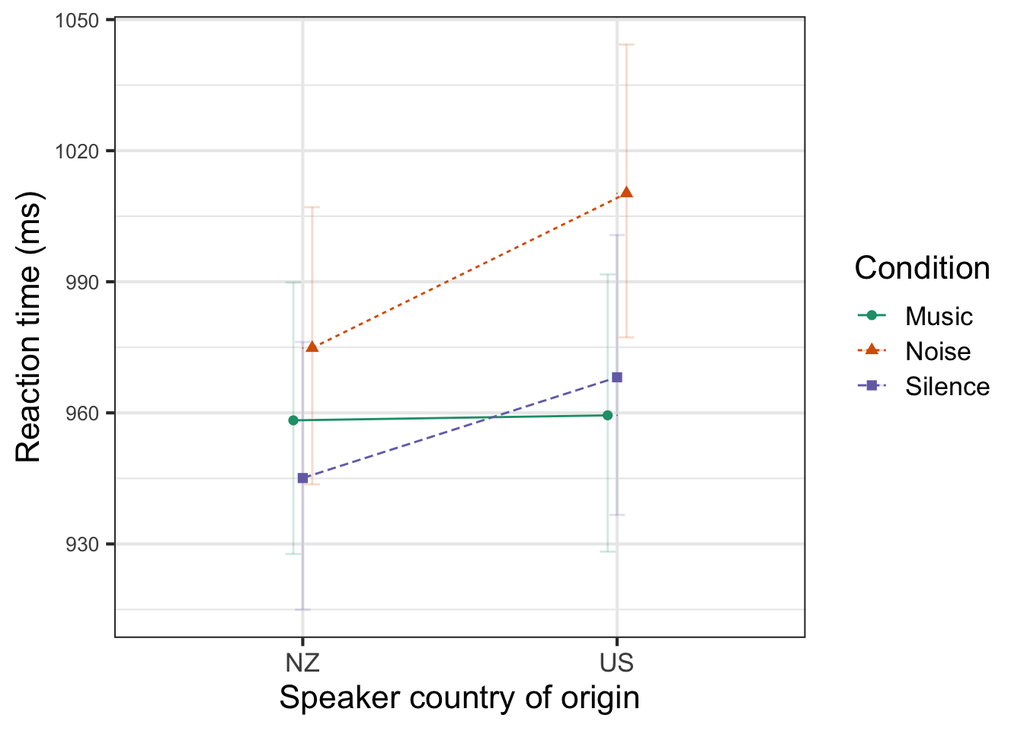

```r
##### PLOT IT!
# first we need to create a dataframe with Effect
effectsDF <- LDT_RT_mod %>%
  Effect(c("Voice","Condition"), .) %>%
  as.data.frame()
### don't worry about the warning, that's just saying it's removed info about the scaling.

# backtransform the RT and standard errors to milliseconds scale
effectsDF$RT <- effectsDF$fit * attr(dat2$RT.lcs, 'scaled:scale') + attr(dat2$RT.lcs, 'scaled:center')
effectsDF$RT <- exp(effectsDF$RT)
effectsDF$lowerRT <- effectsDF$lower * attr(dat2$RT.lcs, 'scaled:scale') + attr(dat2$RT.lcs, 'scaled:center')
effectsDF$lowerRT <- exp(effectsDF$lowerRT)
effectsDF$upperRT <- effectsDF$upper * attr(dat2$RT.lcs, 'scaled:scale') + attr(dat2$RT.lcs, 'scaled:center')
effectsDF$upperRT <- exp(effectsDF$upperRT)

# make a version of voice that let's us see the error bars better
effectsDF$VoiceN <- as.numeric(effectsDF$Voice)
effectsDF$VoiceN <- ifelse(effectsDF$Condition=="Music", effectsDF$VoiceN -.03, effectsDF$VoiceN)
effectsDF$VoiceN <- ifelse(effectsDF$Condition=="Noise", effectsDF$VoiceN +.03, effectsDF$VoiceN)

# PLOT IT
effectsDF  %>%  ggplot(aes(x=VoiceN, y=RT, shape=Condition, colour=Condition, linetype = Condition, group = Condition,  ymin=lowerRT, ymax=upperRT)) +
  geom_line() +
  geom_errorbar(width = 0.05, alpha=0.2, linetype=1) +
  geom_point(data = effectsDF, aes(x = Voice), size =0) +
  geom_point(data = effectsDF, aes(x = VoiceN), size = 2) +
  scale_y_continuous('Reaction time (ms)', n.breaks = 6) +
  scale_x_discrete('Speaker country of origin') +
  theme_bw(base_size=16) + theme(axis.text.y = element_text(size = 10)) +
  scale_colour_brewer(palette = 'Dark2')
```

```r
# export the plot if you like
# ggsave('LDT_mod.png', width=7, height = 5.5)
```

```r
# fit a minimally different version of the model and check significance
LDT_RT_mod_b <- lmer(RT.lcs ~  Condition + Voice + PrevRT.lcs +
              (1 + PrevRT.lcs |Participant) + (1 + Voice | Word),
              data = dat2)


anova(LDT_RT_mod,LDT_RT_mod_b) # 0.01. the interaction improves model fit.
```

```
## refitting model(s) with ML (instead of REML)
```

```
## Data: dat2
## Models:
## LDT_RT_mod_b: RT.lcs ~ Condition + Voice + PrevRT.lcs + (1 + PrevRT.lcs | Participant) + (1 + Voice | Word)
## LDT_RT_mod: RT.lcs ~ Condition * Voice + PrevRT.lcs + (1 + PrevRT.lcs | Participant) + (1 + Voice | Word)
##              npar   AIC   BIC  logLik deviance  Chisq Df Pr(>Chisq)
## LDT_RT_mod_b   12 11336 11413 -5655.7    11312
## LDT_RT_mod     14 11330 11421 -5651.2    11302 9.0682  2    0.01074 *
## ---
## Signif. codes:  0 '***' 0.001 '**' 0.01 '*' 0.05 '.' 0.1 ' ' 1
```